```python
#prepare the invironment
import matplotlib.pyplot as plt
import pandas as pd
import numpy as np
%matplotlib inline
```

```python
unrate = pd.read_csv('unrate.csv')
unrate['DATE'] = pd.to_datetime(unrate['DATE']) #we can also set the format
```

# MatPlotLib

For now there are 2 basic functions:

1. plt.plot() - geneares an empty plot with axis and ticks
2. plt.show() - displays the plot

**%matplotlib inline** - makes plt.plot() empty plot disappear and shows graphs only when plt.show() is called (write in the beginning of the notebook, on/off)

## Framework:

1. Prepare the data
2. Plot the graph
3. Adjust the design

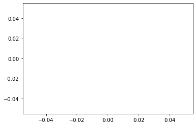

```python
plt.plot()
plt.show()
```

Note, even though no data is plotted, the range is (-0.06, 0.06)

Lets add data to our plot - **plt.plot(x_val, y_val)**

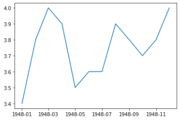

```python
plt.plot(unrate['DATE'][0:12], unrate['VALUE'][0:12])
```

## Rotating X-axes values

In order to avoid values being jammed we can use:

**plt.xticks(rotation = 90)** to rotate x_val by 90 degrees

[output not shown]

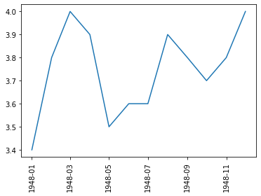

```python
plt.plot(unrate['DATE'][0:12], unrate['VALUE'][0:12])
plt.xticks(rotation = 90)
```

## Adding labels

1. **plt.xlabel()**: accepts a string value, which gets set as the x-axis label.
2. **plt.ylabel()**: accepts a string value, which is set as the y-axis label.
3. **plt.title()**: accepts a string value, which is set as the plot title.

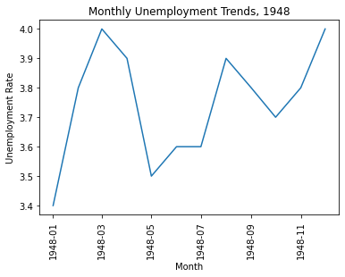

```python
plt.plot(unrate['DATE'][0:12], unrate['VALUE'][0:12])
plt.xticks(rotation = 90)

plt.xlabel('Month')
plt.ylabel('Unemployment Rate')
plt.title('Monthly Unemployment Trends, 1948')
```

## Working with multiple plots (at the same time)

Firstly, our plots should be stored in a special container called "**Figure**" - an object of MatPlotLib.

**Adding plots to the figure (container):**

1. figure = plt.figure( figsize=(width, height) ) - instantiating matplotlib's **Figure object**
2. axes = figure_name.add_subplot(nrows, ncols, index) - instantiating **Axes object** (adding subplot to our figure)

**Creating relevant plot (plot, bar, barh, hist, scatter and etc.):**

1. Axes.plot(x_val, y_val), Axes.bar(), Axes.hist ...

**Adding labels is different**, instead of using plt.xlabel we need to adress to different graphs stored in our figure, therefore:

1. Axes.set_xlabel()
2. Axes.set_ylabel()
3. Axes.set_xticklabels()
4. Axes.set_yticklabels()

**Set-up axes limits:**

1. axes.set_ylim(lower_bound, upper_bound)
2. axes.set_xlim(lower_bound, upper_bound)

### Lets create our first figure container:

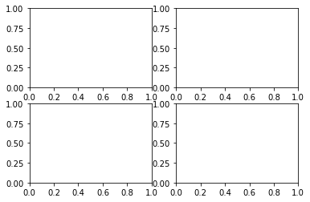

```python
fig = plt.figure()

ax1 = fig.add_subplot(2,2,1)
ax2 = fig.add_subplot(2,2,2)
ax3 = fig.add_subplot(2,2,3)
ax4 = fig.add_subplot(2,2,4)

plt.show()
```

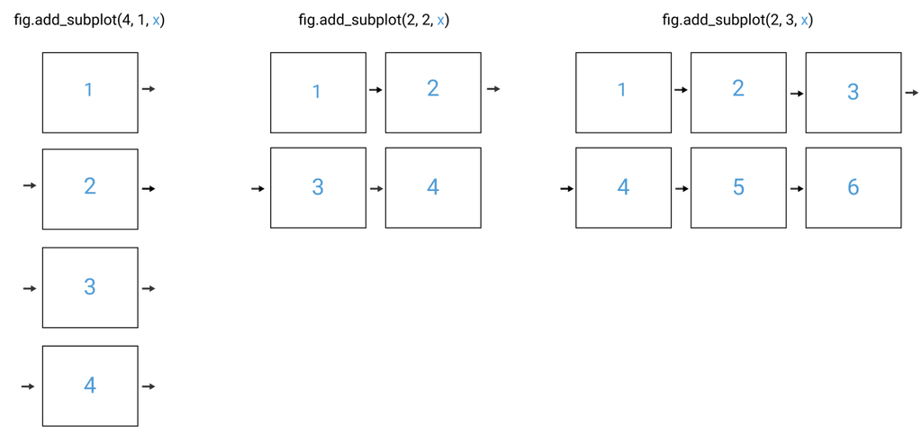

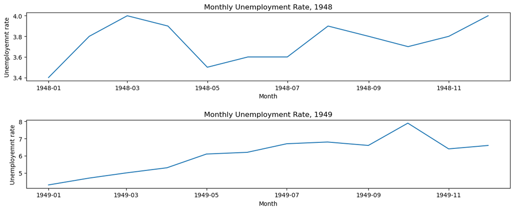

```python
#instantiating figure object and adding plots to it
fig = plt.figure(figsize = (12,5), dpi=100) #also setting the size of the plot, 12dpi wide and 5 dpi high
ax1 = fig.add_subplot(2,1,1)
ax2 = fig.add_subplot(2,1,2)

#plot 1
ax1.plot(unrate['DATE'][0:12], unrate['VALUE'][0:12])

#editing plot 1 appearance
ax1.set_xlabel('Month')
ax1.set_ylabel('Unemployemnt rate')
ax1.set_title('Monthly Unemployment Rate, 1948')

#plot 2
ax2.plot(unrate['DATE'][12:24], unrate['VALUE'][12:24])

#editing plot 2 appearance
ax2.set_title('Monthly Unemployment Rate, 1949')
ax2.set_xlabel('Month')
ax2.set_ylabel('Unemployemnt rate')

plt.tight_layout(h_pad=2) #increases the distance between plots
plt.show()
```

```python
#creating fuction to plot all years within years interval, i.e from 1956 to 1967
def plot_range(first_year, last_year):
    first = first_year - 1948
    last = last_year + 1 - 1948
    periods = last - first

    #making graphs size dynamic (depending on number of graphs)
    fig = plt.figure(figsize = (12, 2.4*periods), dpi=150)

    for i in range(periods):
        ax = fig.add_subplot(periods, 1, i+1)
        start_index = (first+i)*12
        end_index = (first+i+1)*12
        subset = unrate[start_index:end_index]
        ax.plot(subset['DATE'].dt.month, subset['VALUE']) #extracting only month number

        #editing appearance (adding title and axis labels)
        ax.set_title('Monthly Unemployment Rate, {}'.format(first+1948+i))
        ax.set_xlabel('Month')
        ax.set_ylabel('Unemployemnt Rate')

    plt.tight_layout(h_pad=2) #setting space between graphs
    return plt.show()
```

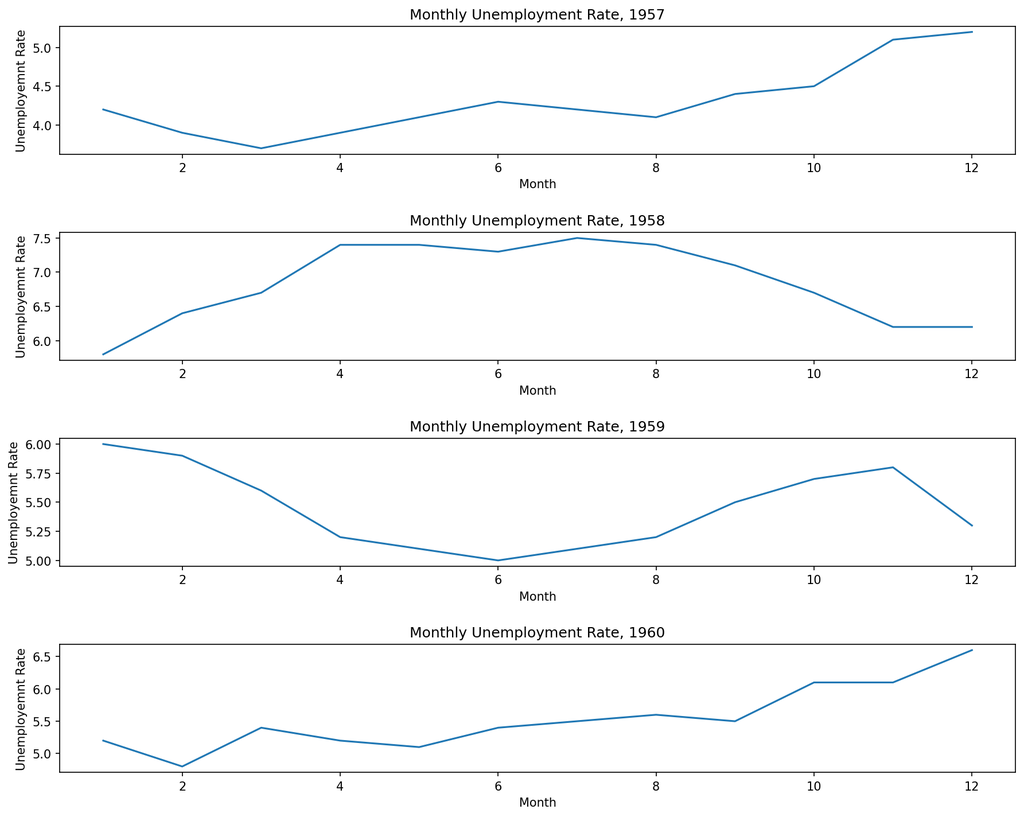

```python
plot_range(1957, 1960)
```

## Plotting multiple graphs in the same area

Previously we would write fig.add_subplot() which creates another plot area. However, if we skip this step and do:

1. fig = plt.figure()
2. plt.plot() - graph 1
3. plt.plot() - graph 2

It will plot 2 graphs in one

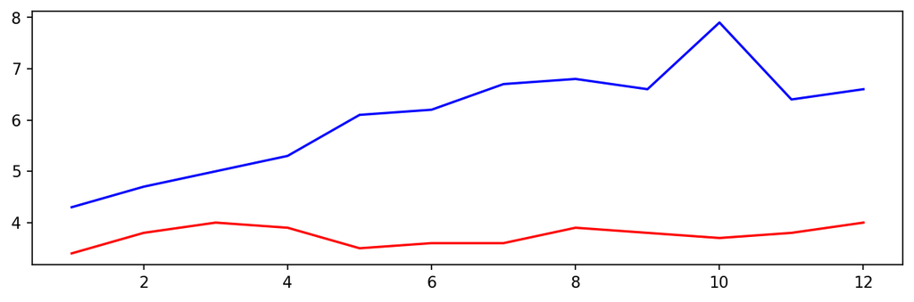

```python
unrate['MONTH'] = unrate['DATE'].dt.month

fig = plt.figure(figsize = (10,3), dpi=150)

plt.plot(unrate['MONTH'][0:12], unrate['VALUE'][0:12], c="red")
plt.plot(unrate['MONTH'][12:24], unrate['VALUE'][12:24], c="blue")

plt.show()
```

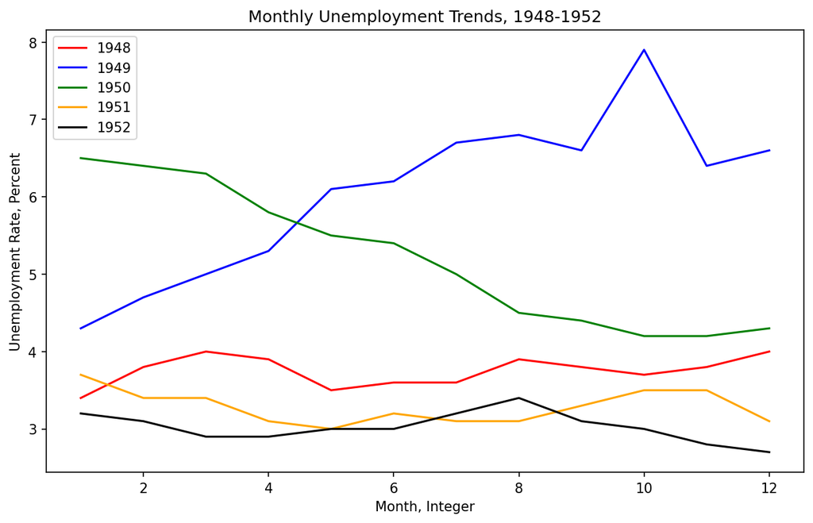

```python
fig = plt.figure(figsize=(10,6), dpi=150)
colors = ['red', 'blue', 'green', 'orange', 'black'] #colors list to be used in a loop

for i in range(5):
    start_index = i*12
    end_index = (i+1)*12
    subset = unrate[start_index:end_index]
    label = str(1948 + i)
    plt.plot(subset['MONTH'], subset['VALUE'], c=colors[i], label=label)

plt.title('Monthly Unemployment Trends, 1948-1952')
plt.xlabel('Month, Integer')
plt.ylabel('Unemployment Rate, Percent')
plt.legend(loc='upper left')
plt.show()
```

## Importing fandango_scores.csv for next **reviews** project

```python
#importing fandango scores csv for the next project
reviews = pd.read_csv('fandango_scores.csv')
reviews.head(5)
```

|  | FILM | RottenTomatoes | RottenTomatoes_User | Metacritic | Metacritic_User | IMDB | Fandango_Stars | Fandango_Ratingvalue | RT_norm | RT_user_norm | ... | IMDB_norm | RT_norm_round | RT_user_norm_round | Metacritic_norm_round | Metacritic_user_norm_round | IMDB_norm_round | Metacritic_user_vote_count | IMDB_user_vote_count | Fandango_votes | Fandango_Difference |
| --- | --- | --- | --- | --- | --- | --- | --- | --- | --- | --- | --- | --- | --- | --- | --- | --- | --- | --- | --- | --- | --- |
| 0 | Avengers: Age of Ultron (2015) | 74 | 86 | 66 | 7.1 | 7.8 | 5.0 | 4.5 | 3.70 | 4.3 | ... | 3.90 | 3.5 | 4.5 | 3.5 | 3.5 | 4.0 | 1330 | 271107 | 14846 | 0.5 |
| 1 | Cinderella (2015) | 85 | 80 | 67 | 7.5 | 7.1 | 5.0 | 4.5 | 4.25 | 4.0 | ... | 3.55 | 4.5 | 4.0 | 3.5 | 4.0 | 3.5 | 249 | 65709 | 12640 | 0.5 |
| 2 | Ant-Man (2015) | 80 | 90 | 64 | 8.1 | 7.8 | 5.0 | 4.5 | 4.00 | 4.5 | ... | 3.90 | 4.0 | 4.5 | 3.0 | 4.0 | 4.0 | 627 | 103660 | 12055 | 0.5 |
| 3 | Do You Believe? (2015) | 18 | 84 | 22 | 4.7 | 5.4 | 5.0 | 4.5 | 0.90 | 4.2 | ... | 2.70 | 1.0 | 4.0 | 1.0 | 2.5 | 2.5 | 31 | 3136 | 1793 | 0.5 |
| 4 | Hot Tub Time Machine 2 (2015) | 14 | 28 | 29 | 3.4 | 5.1 | 3.5 | 3.0 | 0.70 | 1.4 | ... | 2.55 | 0.5 | 1.5 | 1.5 | 1.5 | 2.5 | 88 | 19560 | 1021 | 0.5 |

5 rows × 22 columns

### Quick data cleaning: selecting relevant columns

```python
#selecting only relevant to us columns (instead of 22)
selected_columns = ['FILM', 'RT_user_norm', 'Metacritic_user_nom', 'IMDB_norm', 'Fandango_Ratingvalue','Fandango_Stars']
norm_reviews = reviews.loc[:, selected_columns]

norm_reviews.head(5)
```

|  | FILM | RT_user_norm | Metacritic_user_nom | IMDB_norm | Fandango_Ratingvalue | Fandango_Stars |
| --- | --- | --- | --- | --- | --- | --- |
| 0 | Avengers: Age of Ultron (2015) | 4.3 | 3.55 | 3.90 | 4.5 | 5.0 |
| 1 | Cinderella (2015) | 4.0 | 3.75 | 3.55 | 4.5 | 5.0 |
| 2 | Ant-Man (2015) | 4.5 | 4.05 | 3.90 | 4.5 | 5.0 |
| 3 | Do You Believe? (2015) | 4.2 | 2.35 | 2.70 | 4.5 | 5.0 |
| 4 | Hot Tub Time Machine 2 (2015) | 1.4 | 1.70 | 2.55 | 3.0 | 3.5 |

# Bar Charts

**Creating bar charts:**

1. plt.bar()
2. axes.bar(bar_positions, bar_heights, bar_widths) - **we will use this one for now**
3. axes.barh(bar_positions, bar_heights, bar_widths) - same as axis.bar but with horisontal orientation (barh - bar horisontal)

Plotting bar charts is different because we need to specify more:

1. Bars **positions**
2. Bars **height**
3. Bars **widths**
4. Labels **positions**

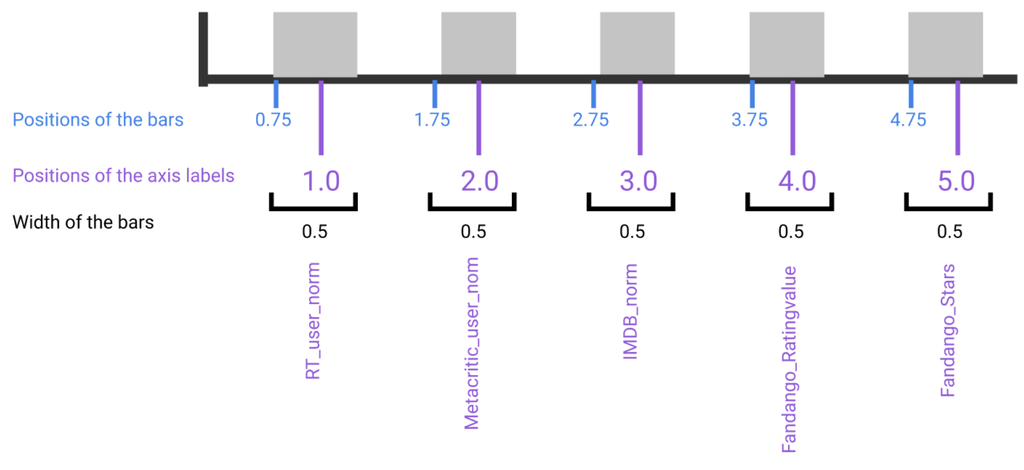

```
<BarContainer object of 5 artists>
```

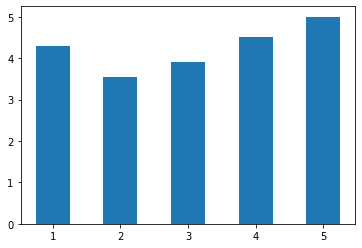

```python
#creating first bar chart
from numpy import arange #creates array range - a_range - arange

#selecting numeric columns
num_col = ['RT_user_norm', 'Metacritic_user_nom', 'IMDB_norm', 'Fandango_Ratingvalue','Fandango_Stars']
bar_heights = norm_reviews[num_col].iloc[0].values
bar_positions = arange(5) + 1

fig, ax = plt.subplots()
ax.bar(bar_positions, bar_heights, 0.5)
```

```python
print('bar_heights   =', arange(5) + 0.75)
print('bar_positions =', norm_reviews[num_col].iloc[0].values)
```

[output not shown]

## Adding labels

Function to add **x-labels**:

1. axes.set_xticks( positions_list ) - specifies where x-labels should be located
2. axes.set_xticklabels( columns_names, rotation=? ) - adds x-labels to specified set_xticks positions

**For y-labels the same as for x-labels (mostly used for horisontal bar charts)**

Adding all other labels **(same as before)**:

1. **plt.xlabel()**: accepts a string value, which gets set as the x-axis label.
2. **plt.ylabel()**: accepts a string value, which is set as the y-axis label.
3. **plt.title()**: accepts a string value, which is set as the plot title.

### Vartical bar chart:

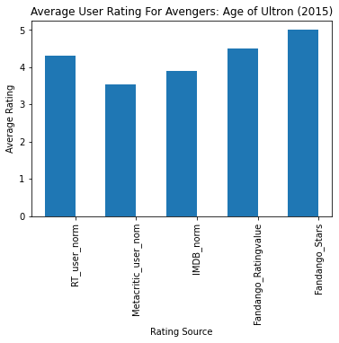

```python
fig, ax = plt.subplots() #creating Figure object and Axis object

tick_positions = range(1,6) #creating x-labels positions list
ax.bar(bar_positions, bar_heights, 0.5) #generating bar chart
ax.set_xticks(tick_positions) #setting x-labels positions
ax.set_xticklabels(num_col, rotation=90) #adding x-labels on previously set-up positions

plt.xlabel('Rating Source')
plt.ylabel('Average Rating')
plt.title('Average User Rating For Avengers: Age of Ultron (2015)')

plt.show()
```

### Horizontal bar chart:

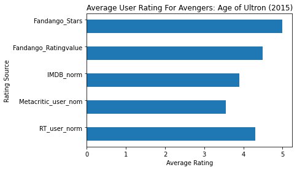

```python
#Horizontal barchart
bar_widths = norm_reviews[num_col].iloc[0].values
bar_positions = arange(5) + 0.75
tick_positions = range(1,6)

fig, ax = plt.subplots()

ax.barh(bar_positions, bar_widths, 0.5)

ax.set_yticks(tick_positions)
ax.set_yticklabels(num_col)

plt.xlabel('Average Rating')
plt.ylabel('Rating Source')
plt.title('Average User Rating For Avengers: Age of Ultron (2015)')

plt.show()
```

# Scatter Plot

Creating scatter plot:

1. axes.scatter(x_val, y_val)

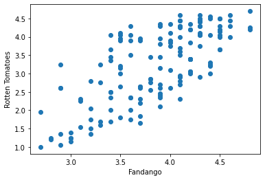

```python
fig, ax = plt.subplots()

ax.scatter(norm_reviews['Fandango_Ratingvalue'], norm_reviews['RT_user_norm'])

plt.xlabel('Fandango')
plt.ylabel('Rotten Tomatoes')

plt.show()
```

# Histogram

**Creating histogram plot:**

1. axes.hist( values, range=(min, max), bins=number)

*range - range in which histogram will be plotted

*bins - number of bins (bars) that the range will have

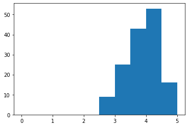

```python
fig = plt.figure()
ax = fig.add_subplot(1,1,1)

ax.hist(norm_reviews['Fandango_Ratingvalue'], range=(0,5))

plt.show()
```

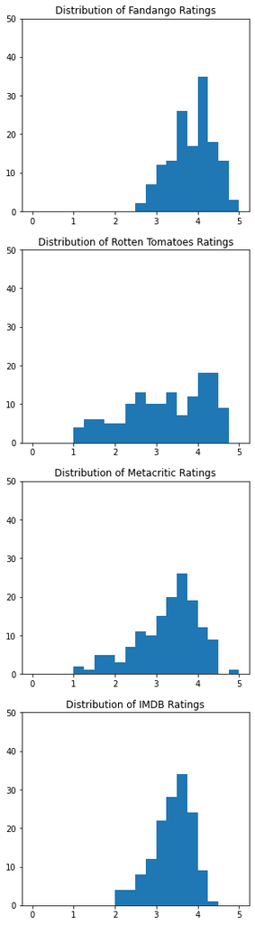

```python
#creating 4 histograms for different rating agencies
#always the same: number of bins, range, ylim range
fig = plt.figure(figsize=(5,20))
ax1 = fig.add_subplot(4,1,1)
ax2 = fig.add_subplot(4,1,2)
ax3 = fig.add_subplot(4,1,3)
ax4 = fig.add_subplot(4,1,4)

ax1.hist(norm_reviews['Fandango_Ratingvalue'],
         bins=20,
         range=(0,5))
ax1.set_title('Distribution of Fandango Ratings')
ax1.set_ylim(0,50)

ax2.hist(norm_reviews['RT_user_norm'],
         bins=20,
         range=(0,5))
ax2.set_title('Distribution of Rotten Tomatoes Ratings')
ax2.set_ylim(0,50)

ax3.hist(norm_reviews['Metacritic_user_nom'],
         bins=20,
         range=(0,5))
ax3.set_title('Distribution of Metacritic Ratings')
ax3.set_ylim(0,50)

ax4.hist(norm_reviews['IMDB_norm'],
         bins=20,
         range=(0,5))
ax4.set_title('Distribution of IMDB Ratings')
ax4.set_ylim(0,50)


plt.show()
```

# Box Plot

**Creating Box Plot:**

1. Axes.boxplot(values)

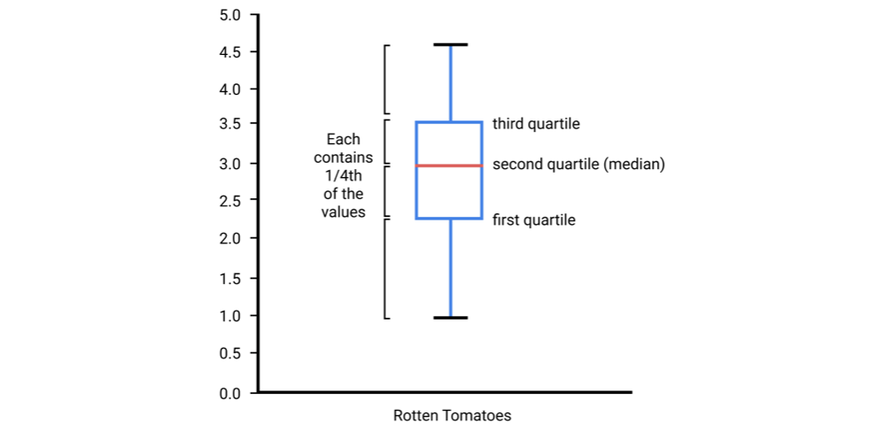

### Box Plot:

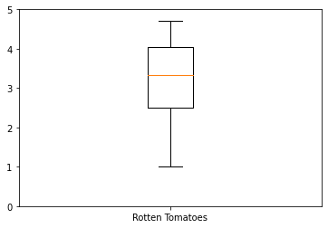

```python
fig = plt.figure() #instantiating Figure object and assigning it to fig variable

ax = fig.add_subplot(1,1,1) #instantiating Axes object and assigning it to ax variable

ax.boxplot(norm_reviews['RT_user_norm']) #creating box plot
ax.set_xticklabels(['Rotten Tomatoes'])
ax.set_ylim(0,5)

plt.show()
```

### Multiple Box Plots:

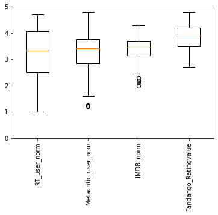

```python
fig = plt.figure()
ax = fig.add_subplot(1,1,1)

num_cols = ['RT_user_norm', 'Metacritic_user_nom', 'IMDB_norm', 'Fandango_Ratingvalue']

ax.boxplot(norm_reviews[num_cols].values)

ax.set_xticklabels(num_cols, rotation=90)
ax.set_ylim(0,5)
plt.show()
```

Circles in the graph above represent **outliers** or extreme values. Outliers are usually treated as abnormal values and affect the overall observation of the data set due to their very high or low values.